# Medicaid Expanion: PQI Models

### PQIs of Interest

For these models, we will be looking at modeling the relationship between various PQIs at the HRR (hospital-referral region) level and Medicaid expansion status. We will be adjusting this relationship using average age of the Medicare population, percent male, percent non-hispanic white, percent african american, percent hispanic, percent eligible for medicaid, and the age category referred to in the PQI.

### Exploratory analysis on covariates

First we quantify the missingness in the covariates and outcomes:

```r
tbl <- hrr %>%
  select(hrr, average_age, percent_male, `percent_non-hispanic_white`, percent_african_american, percent_hispanic, percent_eligible_for_medicaid, `pqi05_copd_or_asthma_in_older_adults_admission_rate_(age_40-64)`, `pqi05_copd_or_asthma_in_older_adults_admission_rate_(age_65-74)`, `pqi05_copd_or_asthma_in_older_adults_admission_rate_(age_75+)`, `pqi07_hypertension_admission_rate_(age_<_65)`,`pqi07_hypertension_admission_rate_(age_65-74)`,  `pqi07_hypertension_admission_rate_(age_75+)`, `pqi08_chf_admission_rate_(age_65-74)`, `pqi08_chf_admission_rate_(age_75+)`, `pqi08_chf_admission_rate_(age_<_65)`) %>%
  summarize_all(.funs = function(x) return(paste0(round(sum(is.na(x))/length(x), 3)*100, "\\%"))) %>% t() %>% data.frame()

names(tbl) <- c("% of Missing values")
kableExtra::kable(tbl)
```

|  | % of Missing values |
| --- | --- |
| hrr | 0% |
| average_age | 0.6% |
| percent_male | 0.6% |
| percent_non-hispanic_white | 0.6% |
| percent_african_american | 0.6% |
| percent_hispanic | 0.6% |
| percent_eligible_for_medicaid | 0.6% |
| pqi05_copd_or_asthma_in_older_adults_admission_rate_(age_40-64) | 0.8% |
| pqi05_copd_or_asthma_in_older_adults_admission_rate_(age_65-74) | 0.6% |
| pqi05_copd_or_asthma_in_older_adults_admission_rate_(age_75+) | 0.6% |
| pqi07_hypertension_admission_rate_(age_<_65) | 30.8% |
| pqi07_hypertension_admission_rate_(age_65-74) | 20% |
| pqi07_hypertension_admission_rate_(age_75+) | 5.6% |
| pqi08_chf_admission_rate_(age_65-74) | 0.6% |
| pqi08_chf_admission_rate_(age_75+) | 0.6% |
| pqi08_chf_admission_rate_(age_<_65) | 1.4% |

We have a very small percentage of missing data in our target covariates and 2 of the 3 PQIs. We believe PQI05 and PQI08 will be reasonable metrics to evaluate outpatient quality and it’s relation to Medicaid expansion.

#### Check correlaton in the covariates

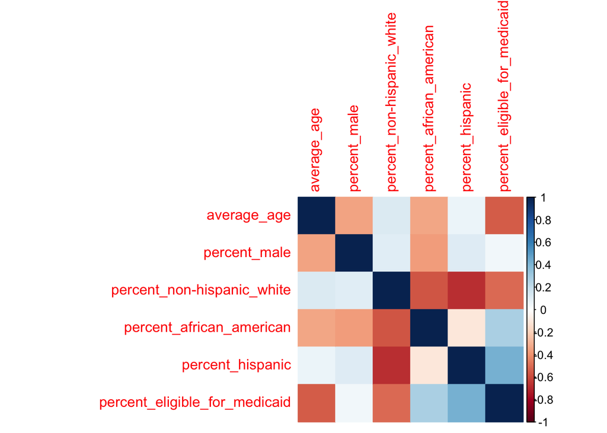

```r
# hrr, average_age, percent_male, `percent_non-hispanic_white`, percent_african_american, percent_hispanic, percent_eligible_for_medicaid, `pqi05_copd_or_asthma_in_older_adults_admission_rate_(age_40-64)`, `pqi05_copd_or_asthma_in_older_adults_admission_rate_(age_65-74)`, `pqi05_copd_or_asthma_in_older_adults_admission_rate_(age_75+)`, `pqi07_hypertension_admission_rate_(age_<_65)`,`pqi07_hypertension_admission_rate_(age_65-74)`,  `pqi07_hypertension_admission_rate_(age_75+)`, `pqi08_chf_admission_rate_(age_65-74)`, `pqi08_chf_admission_rate_(age_75+)`, `pqi08_chf_admission_rate_(age_<_65)`

 hrr %>%
  select(average_age, percent_male, `percent_non-hispanic_white`, percent_african_american, percent_hispanic, percent_eligible_for_medicaid) %>% na.omit() %>% cor() %>% corrplot::corrplot(method = "color")
```

```r
plot_histogram <- function(df, var) {
  df %>% ggplot(aes_string(x = var)) +
    geom_histogram(bins = 20) +
    theme_bw() %>% return()
}
```

Based on the correlation plot, I will remove percent non-hispanic white and average age from the model. I’ll redo the correlation plot without those variables.

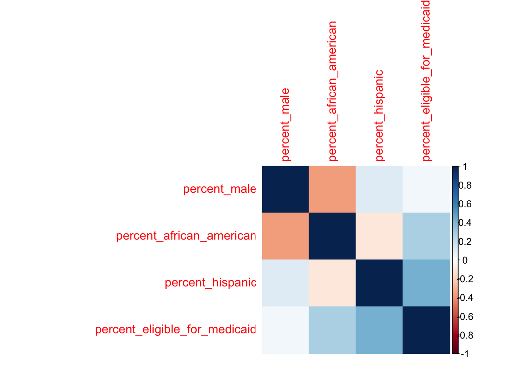

```r
hrr %>%
  select(percent_male, percent_african_american, percent_hispanic, percent_eligible_for_medicaid) %>% na.omit() %>% cor() %>% corrplot::corrplot(method = "color")
```

### Check distribution of outcomes

#### PQI05

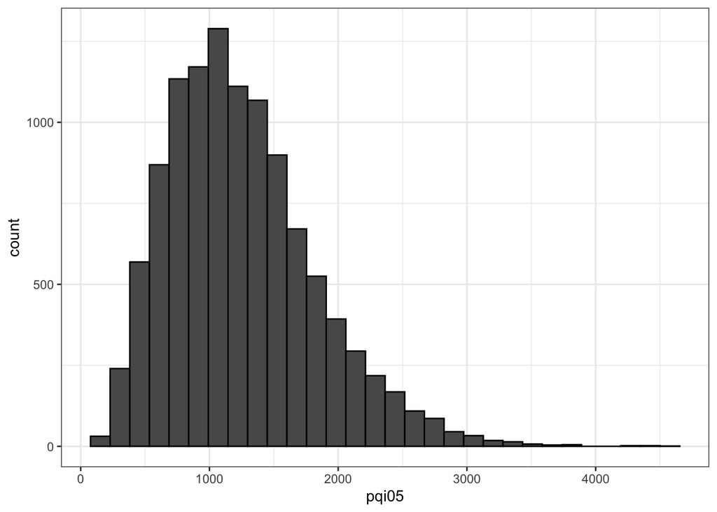

```r
hrr %>%
  filter(!is.na(expansion_status)) %>%
  select(year, `pqi05_copd_or_asthma_in_older_adults_admission_rate_(age_40-64)`, `pqi05_copd_or_asthma_in_older_adults_admission_rate_(age_65-74)`, `pqi05_copd_or_asthma_in_older_adults_admission_rate_(age_75+)`) %>%
  gather(age, pqi05, -year) %>%
  mutate(
    age = str_sub(age, -10)
  ) %>% ggplot(aes( x = pqi05)) + geom_histogram(color = "black") + theme_bw()
```

```r
# Check number of missing values
hrr %>%
  filter(!is.na(expansion_status)) %>%
  select(year, `pqi05_copd_or_asthma_in_older_adults_admission_rate_(age_40-64)`, `pqi05_copd_or_asthma_in_older_adults_admission_rate_(age_65-74)`, `pqi05_copd_or_asthma_in_older_adults_admission_rate_(age_75+)`) %>%
  gather(age, pqi05, -year) %>% pull(pqi05) %>% .[is.na(.)] %>% length()
```

```
## [1] 4
```

With only 4 missing values, we’ll continue with a complete case analysis for this variable

#### PQI08

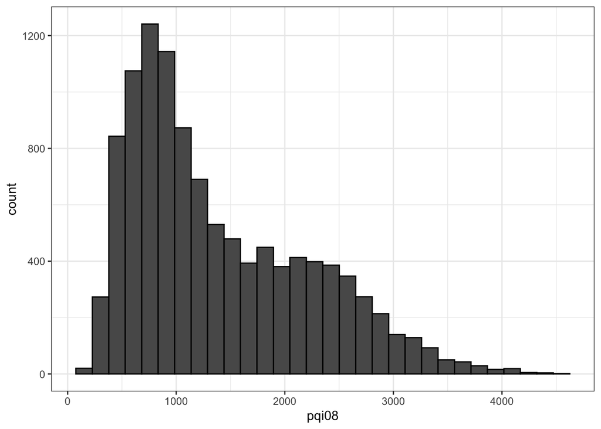

```r
hrr %>%
  filter(!is.na(expansion_status)) %>%
  select(year, `pqi08_chf_admission_rate_(age_65-74)`, `pqi08_chf_admission_rate_(age_75+)`, `pqi08_chf_admission_rate_(age_<_65)`) %>%
  gather(age, pqi08, -year) %>%
  mutate(
    age = str_sub(age, -10)
  ) %>% ggplot(aes( x = pqi08)) + geom_histogram(color = "black") + theme_bw()
```

```r
# Check number of missing values
hrr %>%
  filter(!is.na(expansion_status)) %>%
  select(year, `pqi08_chf_admission_rate_(age_65-74)`, `pqi08_chf_admission_rate_(age_75+)`, `pqi08_chf_admission_rate_(age_<_65)`) %>%
  gather(age, pqi08, -year) %>% pull(pqi08) %>% .[is.na(.)] %>% length()
```

```
## [1] 29
```

With only 29 missing values, we’ll continue with a complete case analysis for this variable. This outcome is almost bi-modally distributed and not normal.

### Model Fitting

#### PQI05

Since these variables are rates, we will want to use Poisson models. There may be overdispersion, so I’m going to start fitting a negative binomial and then check if the poisson version has overdispersion.

```r
pqi05_data <- hrr %>%
  filter(!is.na(expansion_status)) %>%
  select(year, hrr, state, expansion_status,  percent_male, percent_african_american, `percent_hispanic`, percent_eligible_for_medicaid,`pqi05_copd_or_asthma_in_older_adults_admission_rate_(age_40-64)`, `pqi05_copd_or_asthma_in_older_adults_admission_rate_(age_65-74)`, `pqi05_copd_or_asthma_in_older_adults_admission_rate_(age_75+)`) %>%
  gather(age, pqi05, c("pqi05_copd_or_asthma_in_older_adults_admission_rate_(age_40-64)", "pqi05_copd_or_asthma_in_older_adults_admission_rate_(age_65-74)", "pqi05_copd_or_asthma_in_older_adults_admission_rate_(age_75+)")) %>%
  mutate(age = str_extract(age, "(?<=age_).+(?=\\))"))


mod.nb_pqi05 <- MASS::glm.nb(pqi05 ~ `expansion_status` + `percent_male` + `percent_african_american` + percent_hispanic + `percent_eligible_for_medicaid` + `age` + offset(log(year)), data = pqi05_data)
summary(mod.nb_pqi05)
```

```
##
## Call:
## MASS::glm.nb(formula = pqi05 ~ expansion_status + percent_male +
##     percent_african_american + percent_hispanic + percent_eligible_for_medicaid +
##     age + offset(log(year)), data = pqi05_data, init.theta = 8.35361968,
##     link = log)
##
## Deviance Residuals:
##     Min       1Q   Median       3Q      Max
## -4.4650  -0.7770  -0.1415   0.5348   4.1859
##
## Coefficients:
##                                Estimate Std. Error z value Pr(>|z|)
## (Intercept)                    2.423078   0.100970   24.00   <2e-16 ***
## expansion_status2              0.363912   0.010939   33.27   <2e-16 ***
## expansion_status3              0.401069   0.012203   32.87   <2e-16 ***
## expansion_status4              0.362050   0.010593   34.18   <2e-16 ***
## percent_male                  -7.509902   0.222524  -33.75   <2e-16 ***
## percent_african_american       0.031092   0.044387    0.70    0.484
## percent_hispanic              -0.835947   0.041843  -19.98   <2e-16 ***
## percent_eligible_for_medicaid  1.947953   0.055985   34.79   <2e-16 ***
## age65-74                      -0.547949   0.008121  -67.47   <2e-16 ***
## age75+                        -0.232240   0.008116  -28.62   <2e-16 ***
## ---
## Signif. codes:  0 '***' 0.001 '**' 0.01 '*' 0.05 '.' 0.1 ' ' 1
##
## (Dispersion parameter for Negative Binomial(8.3536) family taken to be 1)
##
##     Null deviance: 19987  on 10975  degrees of freedom
## Residual deviance: 11199  on 10966  degrees of freedom
##   (4 observations deleted due to missingness)
## AIC: 162535
##
## Number of Fisher Scoring iterations: 1
##
##
##               Theta:  8.354
##           Std. Err.:  0.112
##
##  2 x log-likelihood:  -162512.753
```

##### Check for quadratic effects of `percent_eligible_for_medicaid`

```r
mod.nb_pqi05_1 <- MASS::glm.nb(pqi05 ~ `expansion_status` + `percent_male` + `percent_african_american` + percent_hispanic + `percent_eligible_for_medicaid` + `age` + percent_eligible_for_medicaid_2+ offset(log(year)), data = pqi05_data %>% mutate(percent_eligible_for_medicaid_2 = percent_eligible_for_medicaid^2))
summary(mod.nb_pqi05_1)
```

```
##
## Call:
## MASS::glm.nb(formula = pqi05 ~ expansion_status + percent_male +
##     percent_african_american + percent_hispanic + percent_eligible_for_medicaid +
##     age + percent_eligible_for_medicaid_2 + offset(log(year)),
##     data = pqi05_data %>% mutate(percent_eligible_for_medicaid_2 = percent_eligible_for_medicaid^2),
##     init.theta = 8.483111512, link = log)
##
## Deviance Residuals:
##     Min       1Q   Median       3Q      Max
## -4.5275  -0.7872  -0.1388   0.5317   4.2223
##
## Coefficients:
##                                  Estimate Std. Error z value Pr(>|z|)
## (Intercept)                      2.180570   0.101768  21.427   <2e-16 ***
## expansion_status2                0.383544   0.010965  34.978   <2e-16 ***
## expansion_status3                0.411703   0.012138  33.917   <2e-16 ***
## expansion_status4                0.373298   0.010552  35.376   <2e-16 ***
## percent_male                    -7.685798   0.221278 -34.734   <2e-16 ***
## percent_african_american         0.032957   0.044056   0.748    0.454
## percent_hispanic                -0.524958   0.047027 -11.163   <2e-16 ***
## percent_eligible_for_medicaid    4.658809   0.209431  22.245   <2e-16 ***
## age65-74                        -0.549280   0.008059 -68.157   <2e-16 ***
## age75+                          -0.231903   0.008054 -28.794   <2e-16 ***
## percent_eligible_for_medicaid_2 -5.633921   0.418303 -13.469   <2e-16 ***
## ---
## Signif. codes:  0 '***' 0.001 '**' 0.01 '*' 0.05 '.' 0.1 ' ' 1
##
## (Dispersion parameter for Negative Binomial(8.4831) family taken to be 1)
##
##     Null deviance: 20294  on 10975  degrees of freedom
## Residual deviance: 11196  on 10965  degrees of freedom
##   (4 observations deleted due to missingness)
## AIC: 162363
##
## Number of Fisher Scoring iterations: 1
##
##
##               Theta:  8.483
##           Std. Err.:  0.113
##
##  2 x log-likelihood:  -162339.028
```

#### Effect Modification

We think there may be effect modification between % eligible for medicaid and expansion status, since in general Medicaid expansion means a higher percentage of the population qualifies for Medicaid.

```r
mod.nb_pqi05_2 <-MASS::glm.nb(pqi05 ~ `expansion_status` + `percent_male` + `percent_african_american` + percent_hispanic + `percent_eligible_for_medicaid` + `age` + percent_eligible_for_medicaid_2+ expansion_status*percent_eligible_for_medicaid + offset(log(year)), data = pqi05_data %>% mutate(percent_eligible_for_medicaid_2 = percent_eligible_for_medicaid^2))
summary(mod.nb_pqi05_2 )
```

```
##
## Call:
## MASS::glm.nb(formula = pqi05 ~ expansion_status + percent_male +
##     percent_african_american + percent_hispanic + percent_eligible_for_medicaid +
##     age + percent_eligible_for_medicaid_2 + expansion_status *
##     percent_eligible_for_medicaid + offset(log(year)), data = pqi05_data %>%
##     mutate(percent_eligible_for_medicaid_2 = percent_eligible_for_medicaid^2),
##     init.theta = 8.568631037, link = log)
##
## Deviance Residuals:
##     Min       1Q   Median       3Q      Max
## -4.4280  -0.7852  -0.1479   0.5342   4.1484
##
## Coefficients:
##                                                  Estimate Std. Error z value
## (Intercept)                                      2.000326   0.103475  19.331
## expansion_status2                                0.308328   0.033096   9.316
## expansion_status3                                0.694193   0.041038  16.916
## expansion_status4                                0.300265   0.031712   9.469
## percent_male                                    -7.231498   0.226164 -31.975
## percent_african_american                         0.154790   0.045311   3.416
## percent_hispanic                                -0.582027   0.047471 -12.261
## percent_eligible_for_medicaid                    4.524902   0.237064  19.087
## age65-74                                        -0.549445   0.008019 -68.517
## age75+                                          -0.231721   0.008014 -28.916
## percent_eligible_for_medicaid_2                 -5.538923   0.421537 -13.140
## expansion_status2:percent_eligible_for_medicaid  0.342275   0.141841   2.413
## expansion_status3:percent_eligible_for_medicaid -1.357398   0.178489  -7.605
## expansion_status4:percent_eligible_for_medicaid  0.300946   0.131443   2.290
##                                                 Pr(>|z|)
## (Intercept)                                      < 2e-16 ***
## expansion_status2                                < 2e-16 ***
## expansion_status3                                < 2e-16 ***
## expansion_status4                                < 2e-16 ***
## percent_male                                     < 2e-16 ***
## percent_african_american                        0.000635 ***
## percent_hispanic                                 < 2e-16 ***
## percent_eligible_for_medicaid                    < 2e-16 ***
## age65-74                                         < 2e-16 ***
## age75+                                           < 2e-16 ***
## percent_eligible_for_medicaid_2                  < 2e-16 ***
## expansion_status2:percent_eligible_for_medicaid 0.015818 *
## expansion_status3:percent_eligible_for_medicaid 2.85e-14 ***
## expansion_status4:percent_eligible_for_medicaid 0.022047 *
## ---
## Signif. codes:  0 '***' 0.001 '**' 0.01 '*' 0.05 '.' 0.1 ' ' 1
##
## (Dispersion parameter for Negative Binomial(8.5686) family taken to be 1)
##
##     Null deviance: 20497  on 10975  degrees of freedom
## Residual deviance: 11194  on 10962  degrees of freedom
##   (4 observations deleted due to missingness)
## AIC: 162256
##
## Number of Fisher Scoring iterations: 1
##
##
##               Theta:  8.569
##           Std. Err.:  0.114
##
##  2 x log-likelihood:  -162225.780
```

The coefficients for the interaction are significant, so we will keep it in the model.

#### Model Diagnostics

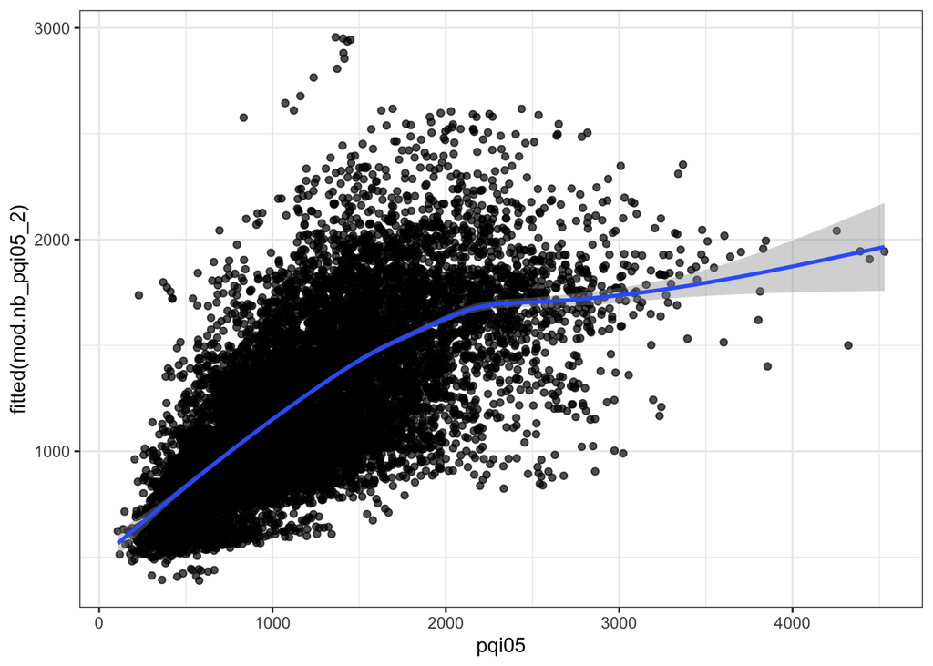

```r
pqi05_data %>%
  na.omit() %>%
  ggplot(aes(x = pqi05, y = fitted(mod.nb_pqi05_2))) +
  geom_point(alpha = 0.7) +
  geom_smooth() +
  theme_bw()
```

##### Check Poisson model

```r
mod.pois_pqi05 <- glm(pqi05 ~ `expansion_status` + `percent_male` + `percent_african_american` + percent_hispanic + `percent_eligible_for_medicaid` + `age` + percent_eligible_for_medicaid_2+ expansion_status*percent_eligible_for_medicaid, offset = log(year), data = pqi05_data %>% mutate(percent_eligible_for_medicaid_2 = percent_eligible_for_medicaid^2), family = "poisson")

# Evaluate overdispersion
deviance(mod.pois_pqi05)/mod.pois_pqi05$df.residual #  138.7201
```

```
## [1] 138.7201
```

```r
pearson.stat_pqi05 <- sum((na.omit(pqi05_data)$pqi05 - fitted(mod.pois_pqi05))^2/fitted(mod.pois_pqi05))
pearson.stat_pqi05/mod.pois_pqi05$df.residual # 144.1579
```

```
## [1] 144.1579
```

```r
# Evidence of overdispersion
mean(pqi05_data$pqi05, na.rm = T) # 1249.904
```

```
## [1] 1249.904
```

```r
var(pqi05_data$pqi05, na.rm = T) # 325943.6
```

```
## [1] 325943.6
```

By these, we can say the negative binomial is the right choice.

#### Interpretation

```r
coef(mod.nb_pqi05_2)
```

```
##                                     (Intercept)
##                                       2.0003258
##                               expansion_status2
##                                       0.3083275
##                               expansion_status3
##                                       0.6941927
##                               expansion_status4
##                                       0.3002646
##                                    percent_male
##                                      -7.2314977
##                        percent_african_american
##                                       0.1547904
##                                percent_hispanic
##                                      -0.5820268
##                   percent_eligible_for_medicaid
##                                       4.5249023
##                                        age65-74
##                                      -0.5494451
##                                          age75+
##                                      -0.2317214
##                 percent_eligible_for_medicaid_2
##                                      -5.5389228
## expansion_status2:percent_eligible_for_medicaid
##                                       0.3422752
## expansion_status3:percent_eligible_for_medicaid
##                                      -1.3573976
## expansion_status4:percent_eligible_for_medicaid
##                                       0.3009459
```

```r
exp(confint(mod.nb_pqi05_2))
```

```
##                                                        2.5 %       97.5 %
## (Intercept)                                     6.034390e+00 9.054446e+00
## expansion_status2                               1.276179e+00 1.451597e+00
## expansion_status3                               1.847346e+00 2.169706e+00
## expansion_status4                               1.270277e+00 1.435093e+00
## percent_male                                    4.629838e-04 1.130631e-03
## percent_african_american                        1.064846e+00 1.280048e+00
## percent_hispanic                                5.079822e-01 6.148085e-01
## percent_eligible_for_medicaid                   5.806953e+01 1.464244e+02
## age65-74                                        5.682550e-01 5.864281e-01
## age75+                                          7.807896e-01 8.057407e-01
## percent_eligible_for_medicaid_2                 1.709239e-03 9.064200e-03
## expansion_status2:percent_eligible_for_medicaid 1.066727e+00 1.859120e+00
## expansion_status3:percent_eligible_for_medicaid 1.811176e-01 3.657415e-01
## expansion_status4:percent_eligible_for_medicaid 1.049344e+00 1.739046e+00
```

#### PQI08

Since these variables are rates, we will want to use Poisson models. There may be overdispersion, so I’m going to start fitting a negative binomial and then check if the poisson version has overdispersion.

```r
pqi08_data <- hrr %>%
  filter(!is.na(expansion_status)) %>%
  select(year, hrr, state, expansion_status,  percent_male, percent_african_american, `percent_hispanic`, percent_eligible_for_medicaid,`pqi08_chf_admission_rate_(age_65-74)`, `pqi08_chf_admission_rate_(age_75+)`, `pqi08_chf_admission_rate_(age_<_65)`) %>%
  gather(age, pqi08, c("pqi08_chf_admission_rate_(age_<_65)", "pqi08_chf_admission_rate_(age_65-74)", "pqi08_chf_admission_rate_(age_75+)")) %>%
  mutate(age = str_extract(age, "(?<=age_).+(?=\\))"))


mod.nb_pqi08 <- MASS::glm.nb(pqi08 ~ `expansion_status` + `percent_male` + `percent_african_american` + percent_hispanic + `percent_eligible_for_medicaid` + `age` + offset(log(year)), data = pqi08_data)
summary(mod.nb_pqi08)
```

```
##
## Call:
## MASS::glm.nb(formula = pqi08 ~ expansion_status + percent_male +
##     percent_african_american + percent_hispanic + percent_eligible_for_medicaid +
##     age + offset(log(year)), data = pqi08_data, init.theta = 12.04476341,
##     link = log)
##
## Deviance Residuals:
##     Min       1Q   Median       3Q      Max
## -4.0260  -0.7317  -0.0961   0.5478   4.4076
##
## Coefficients:
##                                Estimate Std. Error z value Pr(>|z|)
## (Intercept)                    0.842115   0.084365   9.982   <2e-16 ***
## expansion_status2              0.159481   0.009139  17.450   <2e-16 ***
## expansion_status3              0.256869   0.010189  25.211   <2e-16 ***
## expansion_status4              0.146708   0.008843  16.589   <2e-16 ***
## percent_male                  -4.439616   0.185970 -23.873   <2e-16 ***
## percent_african_american       1.746731   0.037032  47.168   <2e-16 ***
## percent_hispanic               0.312481   0.034895   8.955   <2e-16 ***
## percent_eligible_for_medicaid  0.775592   0.046753  16.589   <2e-16 ***
## age65-74                      -0.274105   0.006796 -40.332   <2e-16 ***
## age75+                         0.819164   0.006779 120.847   <2e-16 ***
## ---
## Signif. codes:  0 '***' 0.001 '**' 0.01 '*' 0.05 '.' 0.1 ' ' 1
##
## (Dispersion parameter for Negative Binomial(12.0448) family taken to be 1)
##
##     Null deviance: 45950  on 10950  degrees of freedom
## Residual deviance: 11118  on 10941  degrees of freedom
##   (29 observations deleted due to missingness)
## AIC: 159048
##
## Number of Fisher Scoring iterations: 1
##
##
##               Theta:  12.045
##           Std. Err.:  0.163
##
##  2 x log-likelihood:  -159025.919
```

##### Check for quadratic effects of `percent_eligible_for_medicaid`

```r
mod.nb_pqi08_1 <- MASS::glm.nb(pqi08 ~ `expansion_status` + `percent_male` + `percent_african_american` + percent_hispanic + `percent_eligible_for_medicaid` + `age` + percent_eligible_for_medicaid_2+ offset(log(year)), data = pqi08_data %>% mutate(percent_eligible_for_medicaid_2 = percent_eligible_for_medicaid^2))
summary(mod.nb_pqi08_1)
```

```
##
## Call:
## MASS::glm.nb(formula = pqi08 ~ expansion_status + percent_male +
##     percent_african_american + percent_hispanic + percent_eligible_for_medicaid +
##     age + percent_eligible_for_medicaid_2 + offset(log(year)),
##     data = pqi08_data %>% mutate(percent_eligible_for_medicaid_2 = percent_eligible_for_medicaid^2),
##     init.theta = 12.1405392, link = log)
##
## Deviance Residuals:
##     Min       1Q   Median       3Q      Max
## -4.0739  -0.7263  -0.0963   0.5450   4.3951
##
## Coefficients:
##                                  Estimate Std. Error z value Pr(>|z|)
## (Intercept)                      0.700635   0.085325   8.211   <2e-16 ***
## expansion_status2                0.170850   0.009195  18.581   <2e-16 ***
## expansion_status3                0.263183   0.010173  25.872   <2e-16 ***
## expansion_status4                0.153197   0.008842  17.325   <2e-16 ***
## percent_male                    -4.552656   0.185637 -24.525   <2e-16 ***
## percent_african_american         1.749337   0.036892  47.417   <2e-16 ***
## percent_hispanic                 0.501013   0.039369  12.726   <2e-16 ***
## percent_eligible_for_medicaid    2.397809   0.175574  13.657   <2e-16 ***
## age65-74                        -0.274766   0.006770 -40.587   <2e-16 ***
## age75+                           0.819160   0.006752 121.321   <2e-16 ***
## percent_eligible_for_medicaid_2 -3.370766   0.350466  -9.618   <2e-16 ***
## ---
## Signif. codes:  0 '***' 0.001 '**' 0.01 '*' 0.05 '.' 0.1 ' ' 1
##
## (Dispersion parameter for Negative Binomial(12.1405) family taken to be 1)
##
##     Null deviance: 46312  on 10950  degrees of freedom
## Residual deviance: 11117  on 10940  degrees of freedom
##   (29 observations deleted due to missingness)
## AIC: 158962
##
## Number of Fisher Scoring iterations: 1
##
##
##               Theta:  12.141
##           Std. Err.:  0.164
##
##  2 x log-likelihood:  -158937.946
```

#### Effect Modification

We think there may be effect modification between % eligible for medicaid and expansion status, since in general Medicaid expansion means a higher percentage of the population qualifies for Medicaid.

```r
mod.nb_pqi08_2 <- MASS::glm.nb(pqi08 ~ `expansion_status` + `percent_male` + `percent_african_american` + percent_hispanic + `percent_eligible_for_medicaid` + `age` + percent_eligible_for_medicaid_2+ percent_eligible_for_medicaid*expansion_status + offset(log(year)), data = pqi08_data %>% mutate(percent_eligible_for_medicaid_2 = percent_eligible_for_medicaid^2))
summary(mod.nb_pqi08_2)
```

```
##
## Call:
## MASS::glm.nb(formula = pqi08 ~ expansion_status + percent_male +
##     percent_african_american + percent_hispanic + percent_eligible_for_medicaid +
##     age + percent_eligible_for_medicaid_2 + percent_eligible_for_medicaid *
##     expansion_status + offset(log(year)), data = pqi08_data %>%
##     mutate(percent_eligible_for_medicaid_2 = percent_eligible_for_medicaid^2),
##     init.theta = 12.16674904, link = log)
##
## Deviance Residuals:
##     Min       1Q   Median       3Q      Max
## -4.0867  -0.7258  -0.0940   0.5477   4.3780
##
## Coefficients:
##                                                  Estimate Std. Error z value
## (Intercept)                                      0.634268   0.087106   7.282
## expansion_status2                                0.186611   0.027882   6.693
## expansion_status3                                0.404622   0.034528  11.719
## expansion_status4                                0.210895   0.026696   7.900
## percent_male                                    -4.493580   0.190483 -23.590
## percent_african_american                         1.786420   0.038095  46.893
## percent_hispanic                                 0.495312   0.039903  12.413
## percent_eligible_for_medicaid                    2.528170   0.199480  12.674
## age65-74                                        -0.274424   0.006763 -40.579
## age75+                                           0.819672   0.006745 121.526
## percent_eligible_for_medicaid_2                 -3.254435   0.354462  -9.181
## expansion_status2:percent_eligible_for_medicaid -0.047076   0.119383  -0.394
## expansion_status3:percent_eligible_for_medicaid -0.643629   0.150071  -4.289
## expansion_status4:percent_eligible_for_medicaid -0.260566   0.110566  -2.357
##                                                 Pr(>|z|)
## (Intercept)                                     3.30e-13 ***
## expansion_status2                               2.19e-11 ***
## expansion_status3                                < 2e-16 ***
## expansion_status4                               2.79e-15 ***
## percent_male                                     < 2e-16 ***
## percent_african_american                         < 2e-16 ***
## percent_hispanic                                 < 2e-16 ***
## percent_eligible_for_medicaid                    < 2e-16 ***
## age65-74                                         < 2e-16 ***
## age75+                                           < 2e-16 ***
## percent_eligible_for_medicaid_2                  < 2e-16 ***
## expansion_status2:percent_eligible_for_medicaid   0.6933
## expansion_status3:percent_eligible_for_medicaid 1.80e-05 ***
## expansion_status4:percent_eligible_for_medicaid   0.0184 *
## ---
## Signif. codes:  0 '***' 0.001 '**' 0.01 '*' 0.05 '.' 0.1 ' ' 1
##
## (Dispersion parameter for Negative Binomial(12.1667) family taken to be 1)
##
##     Null deviance: 46411  on 10950  degrees of freedom
## Residual deviance: 11116  on 10937  degrees of freedom
##   (29 observations deleted due to missingness)
## AIC: 158944
##
## Number of Fisher Scoring iterations: 1
##
##
##               Theta:  12.167
##           Std. Err.:  0.164
##
##  2 x log-likelihood:  -158913.782
```

#### Model Diagnostics

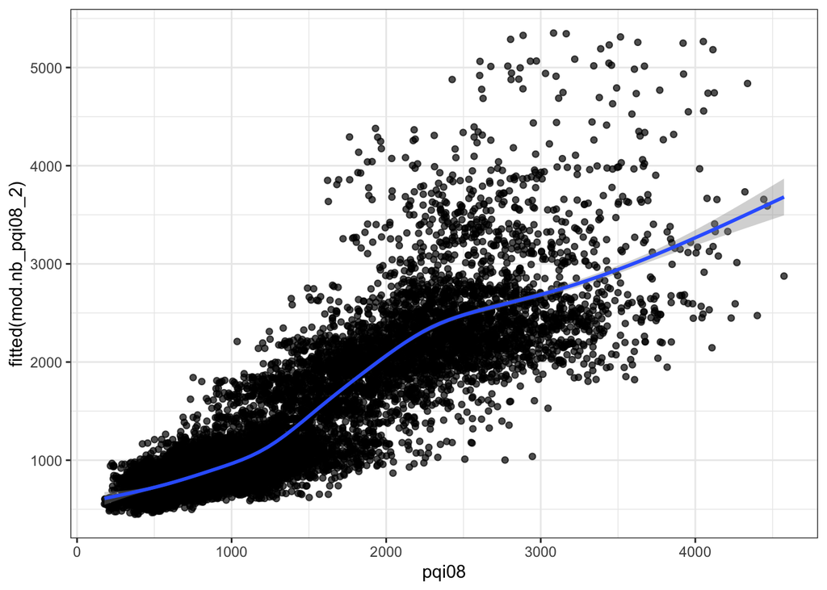

```r
pqi08_data %>%
  na.omit() %>%
  ggplot(aes(x = pqi08, y = fitted(mod.nb_pqi08_2))) +
  geom_point(alpha = 0.7) +
  geom_smooth() +
  theme_bw()
```

##### Check Poisson model

```r
mod.pois_pqi08 <- glm(pqi08 ~ `expansion_status` + `percent_male` + `percent_african_american` + percent_hispanic + `percent_eligible_for_medicaid` + `age` + percent_eligible_for_medicaid_2+ percent_eligible_for_medicaid*expansion_status, offset = log(year), data = pqi08_data %>% mutate(percent_eligible_for_medicaid_2 = percent_eligible_for_medicaid^2), family = "poisson")

# Evaluate overdispersion
deviance(mod.pois_pqi08)/mod.pois_pqi08$df.residual #  98.75487
```

```
## [1] 98.75487
```

```r
pearson.stat_pqi08 <- sum((na.omit(pqi08_data)$pqi08 - fitted(mod.pois_pqi08))^2/fitted(mod.pois_pqi08))
pearson.stat_pqi08/mod.pois_pqi08$df.residual # 99.92519
```

```
## [1] 99.92519
```

```r
# Evidence of overdispersion
mean(pqi08_data$pqi08, na.rm = T) #  1396.131
```

```
## [1] 1396.131
```

```r
var(pqi08_data$pqi08, na.rm = T) # 669616.2
```

```
## [1] 669616.2
```

By these, we can say the negative binomial is the right choice.

#### Interpretation

```r
coef(mod.nb_pqi08_2)
```

```
##                                     (Intercept)
##                                      0.63426832
##                               expansion_status2
##                                      0.18661076
##                               expansion_status3
##                                      0.40462227
##                               expansion_status4
##                                      0.21089471
##                                    percent_male
##                                     -4.49358007
##                        percent_african_american
##                                      1.78641973
##                                percent_hispanic
##                                      0.49531195
##                   percent_eligible_for_medicaid
##                                      2.52816995
##                                        age65-74
##                                     -0.27442370
##                                          age75+
##                                      0.81967240
##                 percent_eligible_for_medicaid_2
##                                     -3.25443527
## expansion_status2:percent_eligible_for_medicaid
##                                     -0.04707637
## expansion_status3:percent_eligible_for_medicaid
##                                     -0.64362936
## expansion_status4:percent_eligible_for_medicaid
##                                     -0.26056592
```

```r
exp(confint(mod.nb_pqi08_2))
```

```
##                                                       2.5 %      97.5 %
## (Intercept)                                     1.586506347  2.24131789
## expansion_status2                               1.141200851  1.27259059
## expansion_status3                               1.401515732  1.60266133
## expansion_status4                               1.172875047  1.29989803
## percent_male                                    0.007652943  0.01633597
## percent_african_american                        5.524897110  6.44739466
## percent_hispanic                                1.515213998  1.77759803
## percent_eligible_for_medicaid                   8.455761108 18.54796071
## age65-74                                        0.749967883  0.77018640
## age75+                                          2.239792476  2.30012017
## percent_eligible_for_medicaid_2                 0.019024975  0.07847272
## expansion_status2:percent_eligible_for_medicaid 0.754217239  1.20688146
## expansion_status3:percent_eligible_for_medicaid 0.392397869  0.70357760
## expansion_status4:percent_eligible_for_medicaid 0.623064550  0.95284009
```